# Лабораторная работа №7

Компьютерный практикум по статистическому анализу данных

Амуничников Антон Игоревич

1132227133@pfur.ru

Российский университет дружбы народов

2025-12-04

# Информация

## Докладчик

- Амуничников Антон Игоревич
- Группа: НПИбд-01-22
- Российский университет дружбы народов им. П. Лумумбы
- 1132227133@pfur.ru

# Вводная часть

## Цель работы

- Основной целью работы является освоение специализированных пакетов Julia для обработки данных.

## Задание

1. Используя JupyterLab, повторите примерыи. При этом дополните графики обозначениями осей координат, легендой с названиями траекторий, названиями графиков и т.п.
2. Выполните задания для самостоятельной работы.

# Выполнение лабораторной работы

## Выполнение примеров

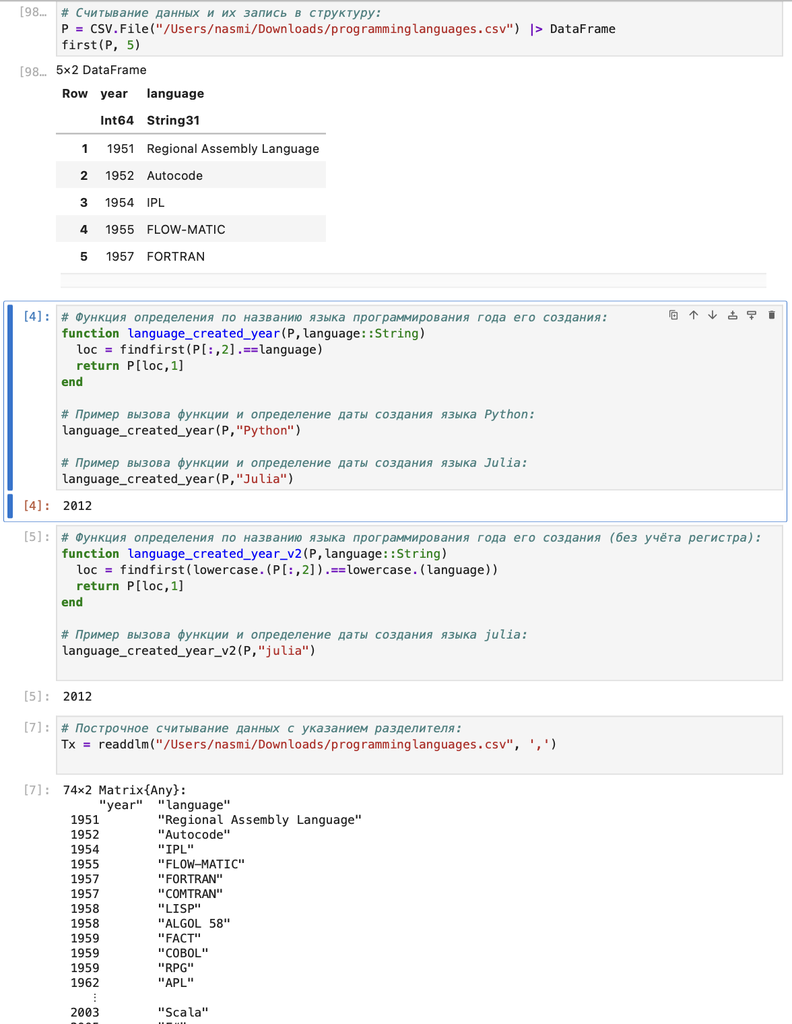

Рисунок 1: Считывание данных

## Выполнение примеров

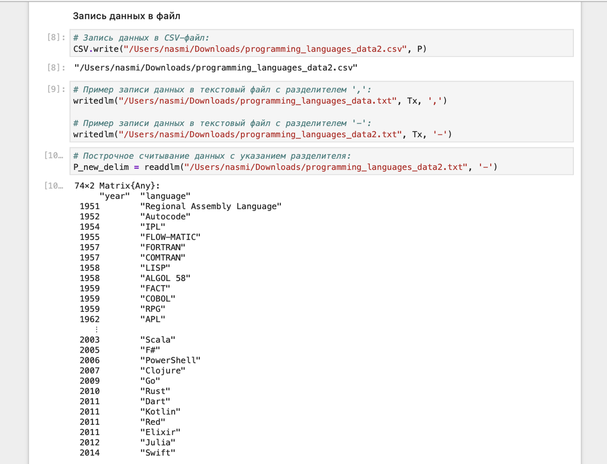

Рисунок 2: Запись данных в файл

## Выполнение примеров

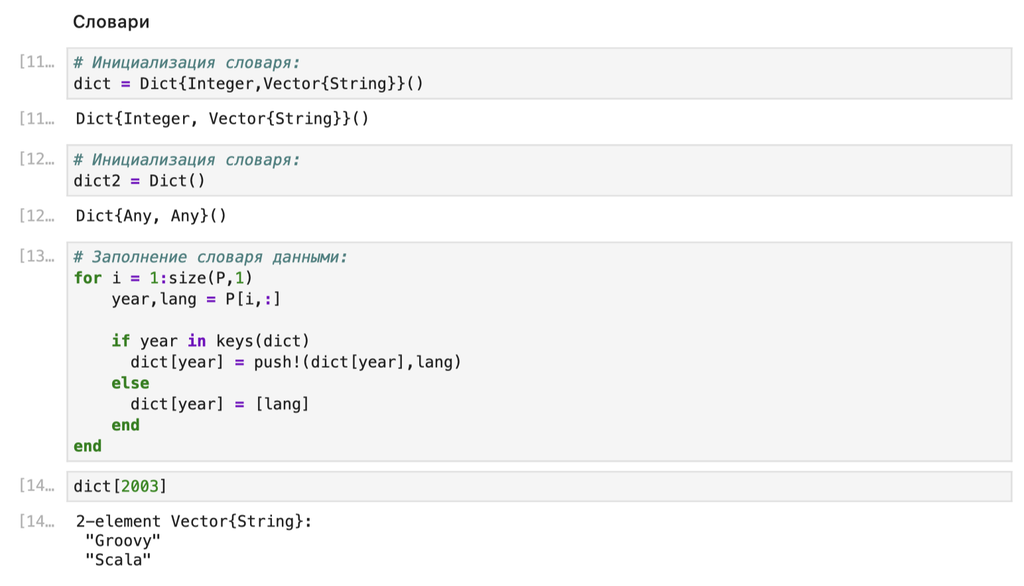

Рисунок 3: Словари

## Выполнение примеров

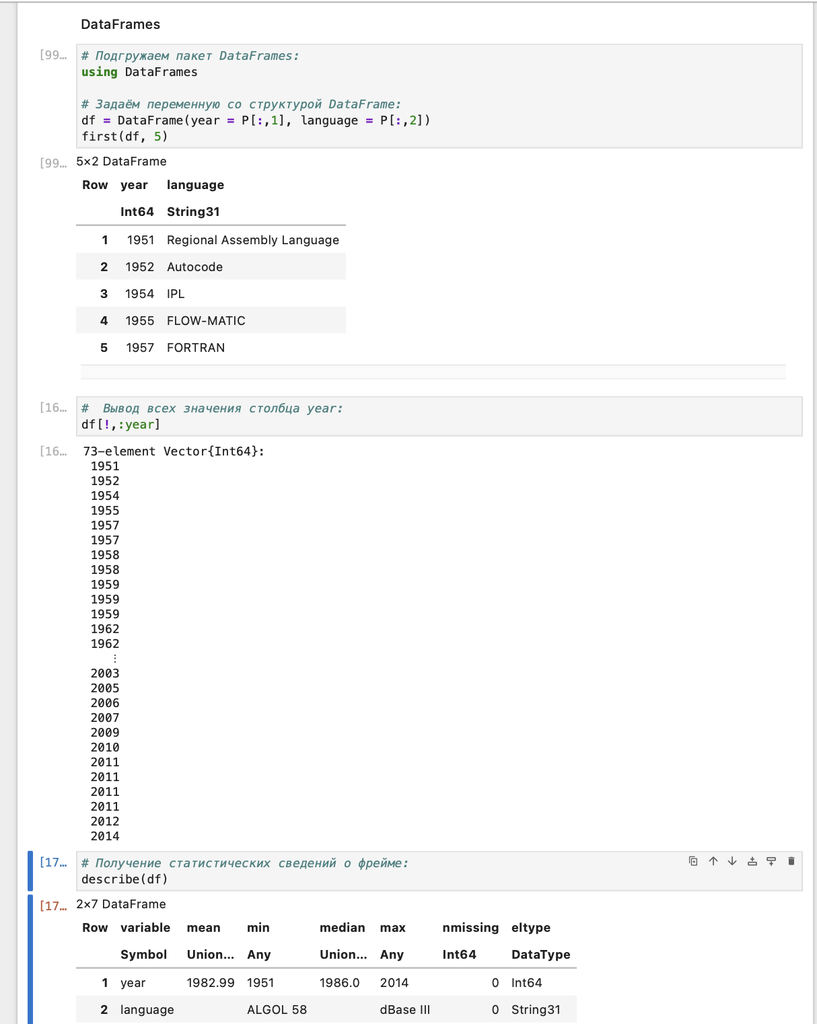

Рисунок 4: DataFrames

## Выполнение примеров

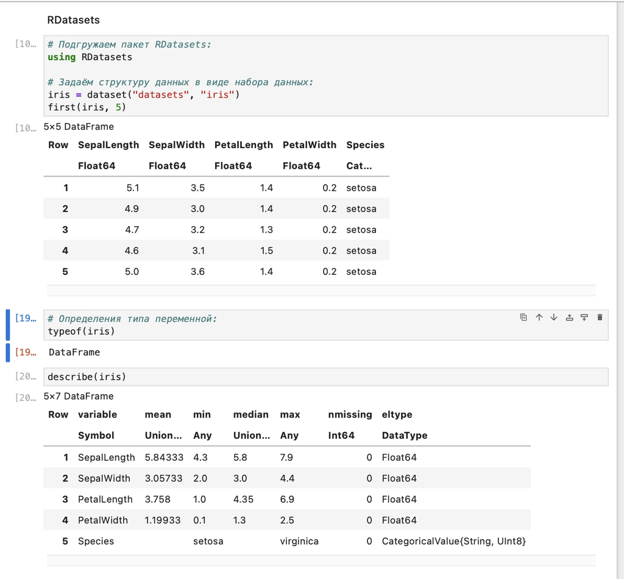

Рисунок 5: RDatasets

## Выполнение примеров

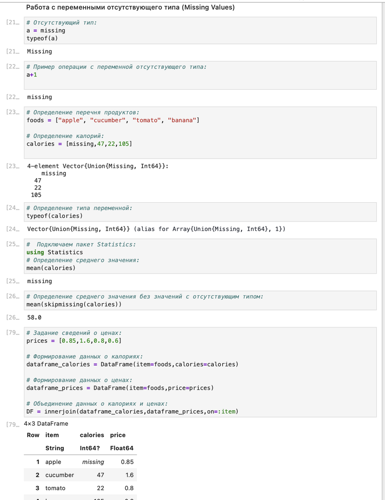

Рисунок 6: Работа с переменными отсутствующеготипа (MissingValues)

## Выполнение примеров

[figure not shown]

Рисунок 7: FileIO

## Выполнение примеров

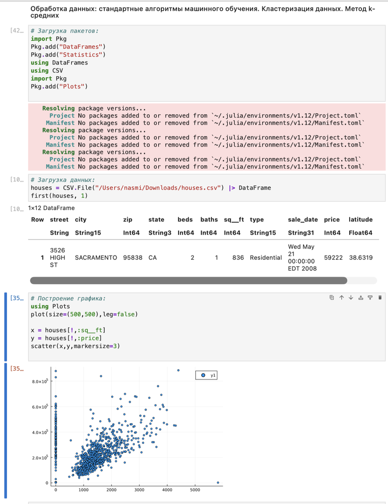

Рисунок 8: Кластеризация данных. Метод k-средних

## Выполнение примеров

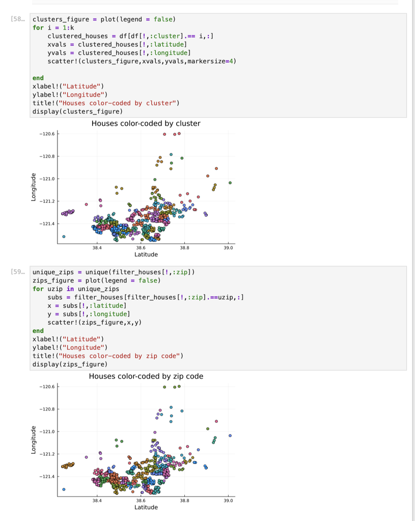

Рисунок 9: Кластеризация данных. Метод k-средних

## Выполнение примеров

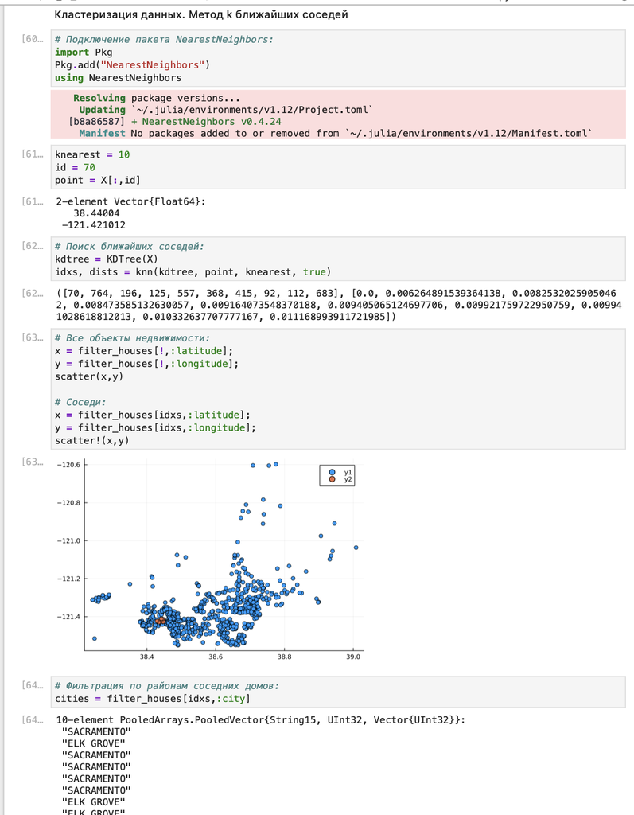

Рисунок 10: Кластеризация данных. Метод k ближайших соседей

## Выполнение примеров

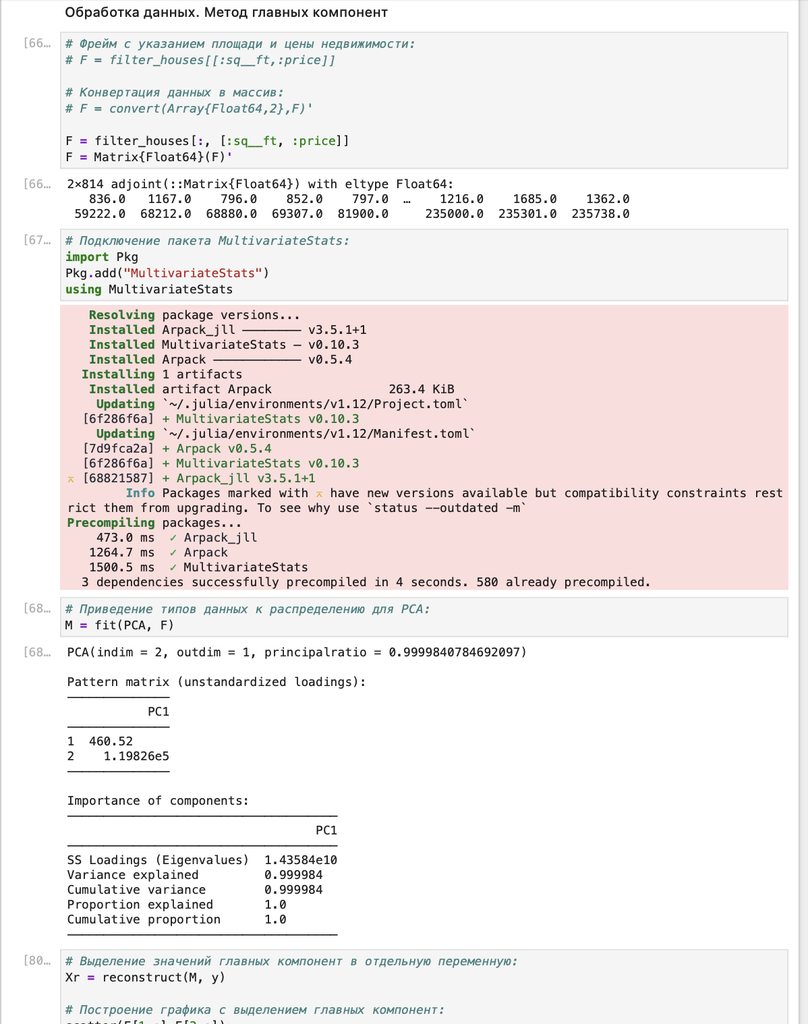

Рисунок 11: Обработка данных. Метод главных компонент

## Выполнение примеров

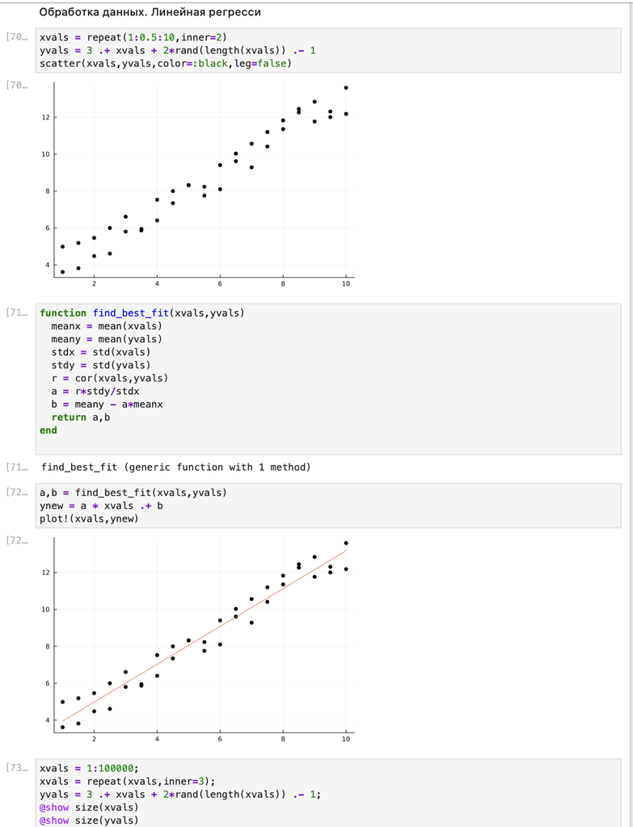

Рисунок 12: Обработка данных. Линейная регрессия

## Выполнение примеров

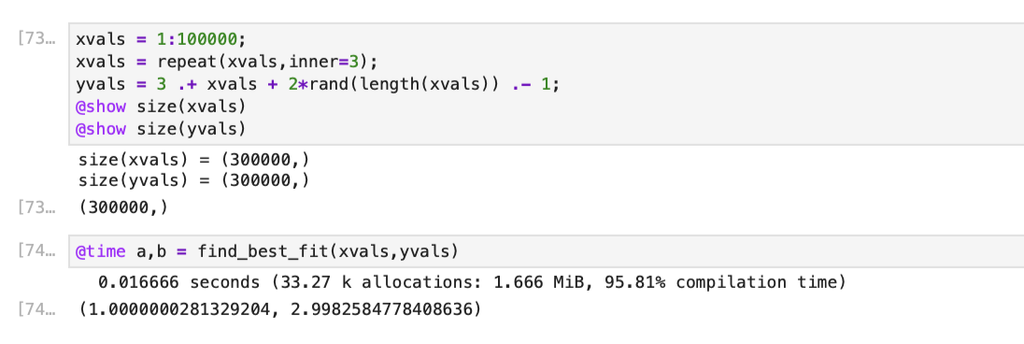

Рисунок 13: Обработка данных. Линейная регрессия

# Самостоятельная работа

## Задание 1: Кластеризация

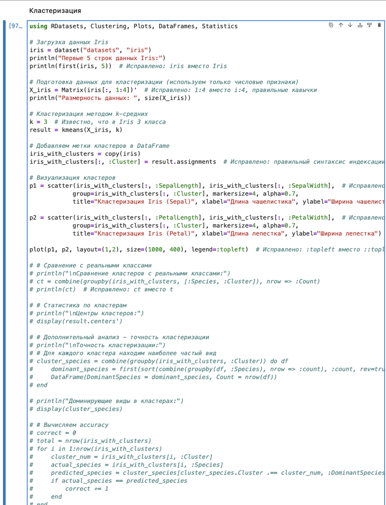

Рисунок 14: Кластеризация

## Задание 1: Кластеризация

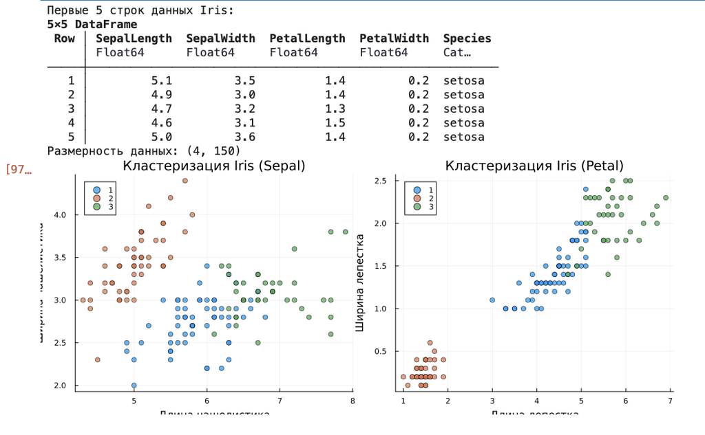

Рисунок 15: Кластеризация

## Задание 2: Регрессия

Пусть регрессионная зависимость является линейной. Матрица наблюдений факторов $X$ имеет размерность $N \times 3$ `randn (N, 3)`, массив результато в $N \times 1$, регрессионная зависимость является линейной. Найдем МНК-оценку для линейной модели.

## Задание 2: Регрессия

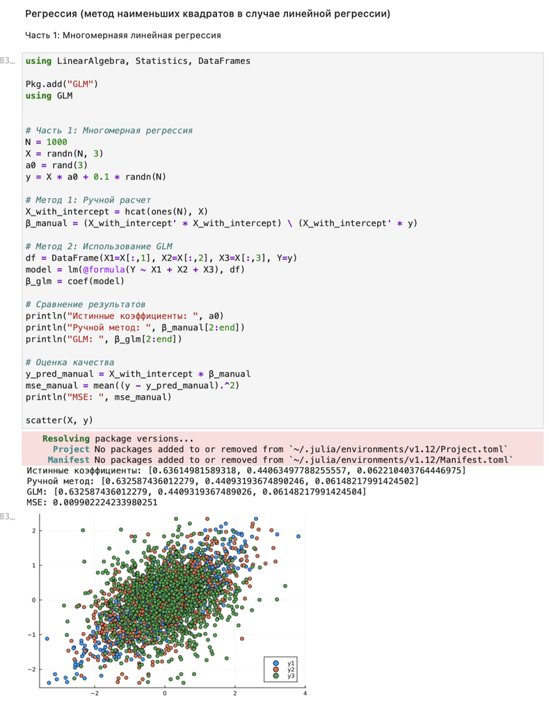

Рисунок 16: Регрессия

## Задание 2: Регрессия

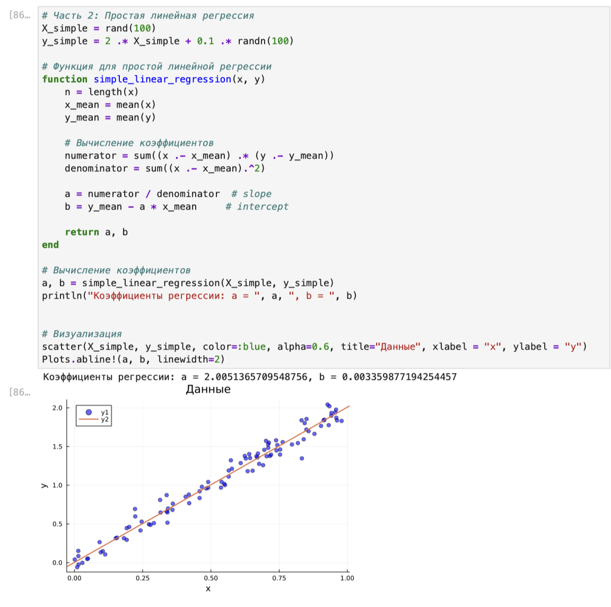

Рисунок 17: Регрессия

## Задание 3: Модельценообразования биномиальных опционов

Построим траекторию возможных цен на акции:

## Задание 3: Модельценообразования биномиальных опционов

Пусть $S = 100, \, T = 1, \, n = 10000, \, \sigma = 0.3$ и $r = 0.08$. Попробуем построить траекторию курса акций.

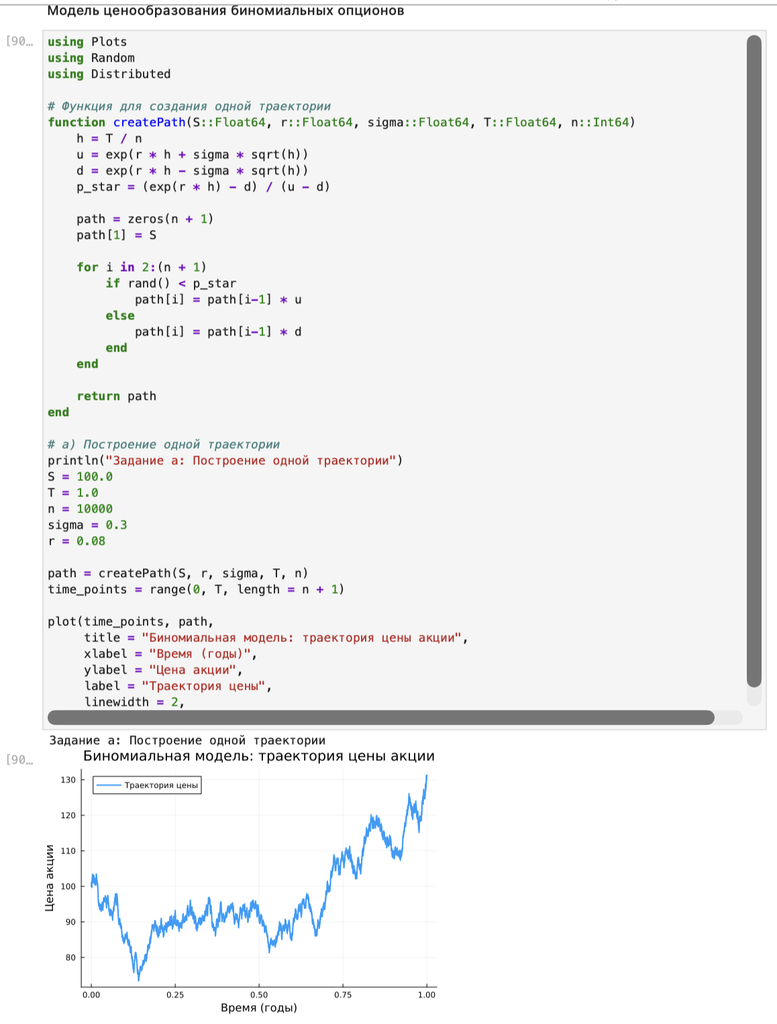

Рисунок 18: Модель ценообразования биномиальных опционов

## Задание 3: Модельценообразования биномиальных опционов

Создадим функцию `createPath (S ::Float64, r ::Float64, sigma ::Float64, T ::Float64, n ::Int64)`, которая создает траекторию цены акции с учетом начальных параметров. Используем `createPath`, чтобы создать 10 разных траекторий и построим их все на одном графике.

## Задание 3: Модельценообразования биномиальных опционов

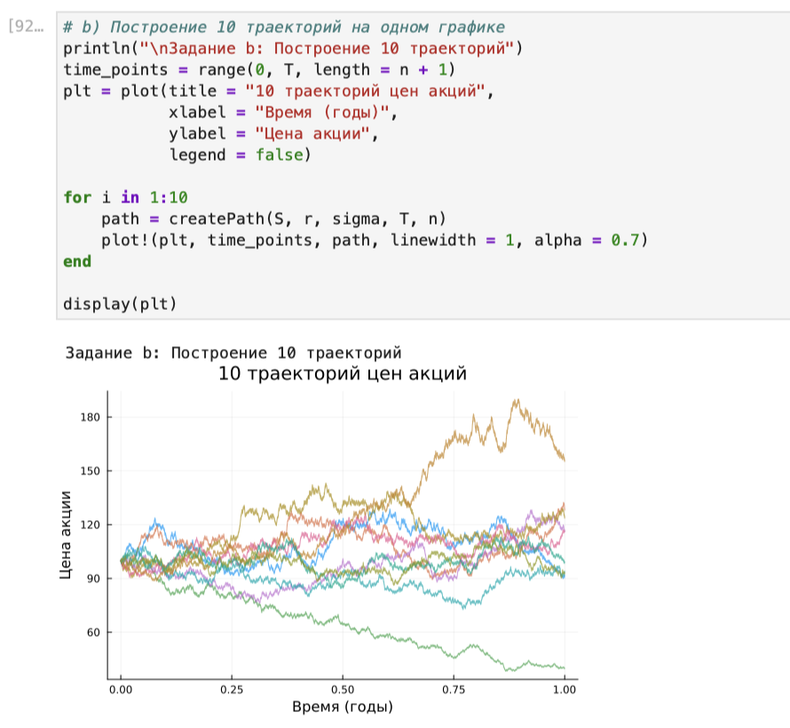

Рисунок 19: Модель ценообразования биномиальных опционов

## Задание 3: Модельценообразования биномиальных опционов

Распараллелим генерацию траектории. Можем использовать `Threads.@threads`, `pmap` и `@parallel`.

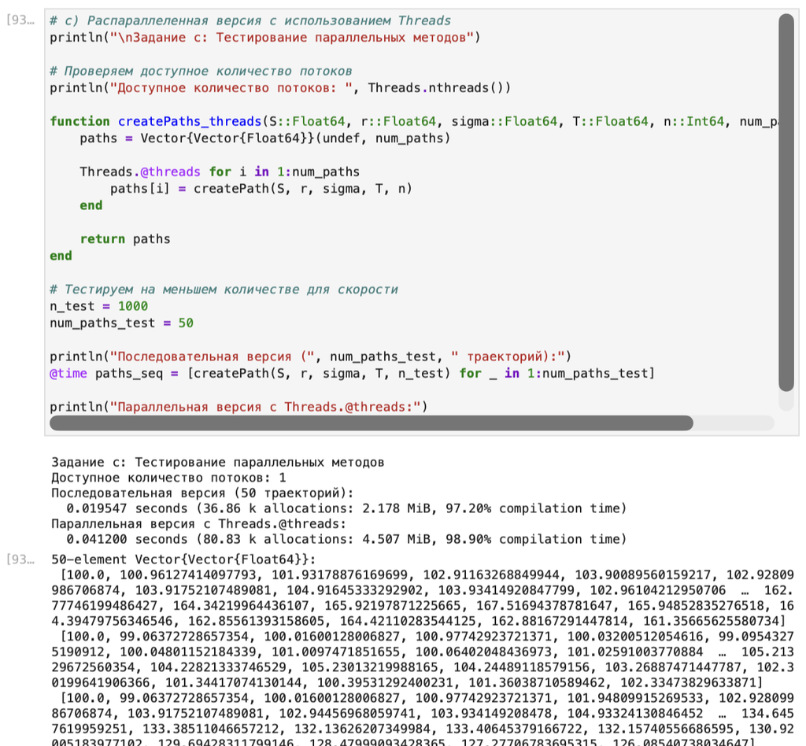

Рисунок 20: Распараллелим генерацию траектории

## Выводы

- В результате выполнения данной лабораторной работы я освоил специализированные пакеты Julia для обработки данных.